# Paired HLA-I Presentation Shifts Sense Intracellular State Across Genotypes

Report 00 — Master Study Index, Biological & Mathematical Formulation, Cohort Inventory, and Navigation Hub

Amir Asiaee, Nebojša Jojić, Elizabeth J. Phillips, and Simon A. Mallal

November 22, 2026

# 1 Executive Summary

Throughout this study, collaborating with Nebojša Jojić and Simon Mallal kept every geometric representation tied directly to antigen-processing mechanisms and donor HLA anchor pockets rather than generic feature engineering.

# 2 Biological Question and Mathematical Formulation

## 2.1 Layer 1 — Everyday-English Biology

Every nucleated human cell continuously shreds a sample of the proteins it is actively building and displays short 8-to-11-residue fragments—dominated by 9-amino-acid peptides—on cell-surface HLA class I (`HLA-A`, `HLA-B`, and `HLA-C`) docking molecules so circulating CD8$^+$ T cells can inspect what is happening inside. Unlike bulk protein snapshots stored inside the cell, surface HLA-I display feeds heavily on newly made proteins tagged with ubiquitin chains (`K-epsilon-GG` tryptic remnants) for rapid proteasomal destruction. Once cut, cytosolic peptide precursors pass into the endoplasmic reticulum (ER) either through the `TAP1/TAP2` peptide pump or, for secreted and membrane leader segments, directly during translation through the `Sec61` channel. Inside the ER, the aminopeptidase `ERAP1` trims extended ends while chaperone editors (`TAPBP`, `PDIA3`, `CALR`, `GANAB`) select stable peptides for export.

Because every person inherits a different set of up to six HLA-A, HLA-B, and HLA-C alleles—each favoring distinct anchor amino acids at positions P2 and P9—comparing a single tumor biopsy from one patient against another mainly reveals whose HLA alleles are present and how many immune or blood-vessel cells infiltrated the sample. We asked whether measuring the **before-versus-after compositional shift** within the same donor or cell line strips away inherited HLA genotype dominance and exposes a conserved, whole-repertoire chemical signature of intracellular signaling (such as interferon-$\gamma$ inflammation versus MAPK kinase blockade and drug resistance).

## 2.2 Layer 2 — Pure Mathematical Formulation

Let $\mathcal{P}$ denote canonical 9-mer peptides over the 20 standard amino acids $\mathcal{A}$. For biological sample $s$ with nonnegative mass-spectrometric intensities $a_{sp} \ge 0$ ($\sum_{p' \in \mathcal{P}} a_{sp'} > 0$), we normalize the repertoire onto the probability simplex:
$$\pi_{sp} \;=\; \frac{a_{sp}}{\sum_{p' \in \mathcal{P}} a_{sp'}},
\qquad \sum_{p \in \mathcal{P}} \pi_{sp} = 1.$$
Given any fixed linear sequence map $\Phi \in \mathbb{R}^{d \times |\mathcal{P}|}$, sample $s$ has compositional summary $q_s = \Phi \pi_s \in \mathbb{R}^d$. For any paired baseline-versus-perturbation contrast $(s_0, s_1)$ sharing donor HLA genotype, the **paired presentation-state shift** is
$$\Delta q_s \;=\; \Phi(\pi_{s,1} - \pi_{s,0}).$$

- **Pointwise concentration-readout test (`Module 1`):** $\Delta\log_2 \mathrm{Pep}_p = \alpha + \beta_{\mathrm{Prot}}\,\Delta\log_2 \mathrm{Prot}_{g(p)} + \varepsilon_p$, disattenuated for replicate reliability via $R^2_{\mathrm{disatt}} = \min\!\big(1,\, R^2_{\mathrm{raw}} / (\hat{\rho}_{\mathrm{Pep}}\hat{\rho}_{\mathrm{Prot}})\big)$ and tested against multiplicity-matched Gaussian sibling-split nulls $\mathcal{N}(0, s_{\Delta,i}^2)$.
- **Representation hierarchy (`Proposition 1` & `Module 7`):** We benchmark nuisance quantity/length (`R0`), anchor-blind P4–P7 physicochemical pair frequencies `Coarse96` ($\mathrm{rank}(\Phi) = 67$, affine simplex dimension $66$), P2+P9 anchor marginals `Anchor40` (`R2c`), full $9 \times 20$ positional marginals `PosAA180` (`R2`), RBF kernel (`R3`), exact peptide identity $\pi_s$ (`R4`), and source-gene shares (`R5`/`R5b`).
- **Linear molar heavy-chain gain (`Module 3` / `Falsifications`):** For log$_2$ baseline and treated HLA-A/B abundances $(A_0, B_0)$ and $(A_1, B_1)$, the molar heavy-chain gain ratio is $\Delta M_B / \Delta M_A = (2^{B_1} - 2^{B_0}) / (2^{A_1} - 2^{A_0})$.
- **Detection-floor bounds (`Module 3`):** Source-adjusted pathway shifts $\theta$ evaluate missing treated detections ($n_1 = 0$) at survival-only, run minimum ($L_{1,\min}$), 1st percentile ($L_{1,p01}$), and 5th percentile ($L_{1,p05}$) detection bounds.
- **Target estimands & assumptions:** Cross-lineage and zero-HLA-overlap decoders predict intervention class $Y \in \{\text{IFN-}\gamma,\, \text{MAPKi}\}$ from $\Delta q_s$ using outer leave-one-lineage-out (LOLO) and leave-one-study-out (LOSO) splits; valid transfer requires within-donor pairing to cancel static HLA allele preference and sufficient depth ($M \ge 500\text{--}2{,}000$ 9-mers).

## 2.3 Terms Used Here

- **9-mer compositional simplex ($\pi_s$):** Relative intensity shares of all detected 9-residue peptides summing to 1, removing bulk ion-current scale.
- **Sibling peptides:** Distinct HLA-I peptides excised from the exact same parent gene; under nascent turnover, sibling peptides can move in opposite directions even when bulk protein abundance rises.
- **P2 and P9 anchors vs. P4–P7 core:** End residues (positions 2 and 9) that lock into the polymorphic HLA-I binding pockets, versus central residues (positions 4 to 7) that face outward toward T-cell receptors.
- **LOLO / LOSO:** Leave-one-lineage-out and leave-one-study-out cross-validation holding out entire cell backgrounds or whole studies during training and penalty selection.
- **Left-censored detection floor (LOD):** Non-detection of down-regulated peptides in treated MS runs because intensity drops below the instrument detection limit rather than remaining unchanged.
- **Sec61 co-translational bypass:** Entry of N-terminal `1–35 AA` cleaved signal peptides directly into the ER during translation, bypassing `TAP1/TAP2` deletion.

# 3 Public Cohort Inventory and Report Navigation

```python
cohorts_tbl = pd.DataFrame([
    {"Cohort": "Stopfer CDK4/6i melanoma", "Accessions": "PXD017407, GSE144373", "System_Units": "4 melanoma lines (SKMEL5/28/2, IPC298); 48 TMT channels", "Modalities": "HipMHC TMT HLA-I; SKMEL5 RNA-seq", "Role": "Paired MAPKi/CDK4/6i reference & channel audit"},
    {"Cohort": "Newey colorectal PDO", "Accessions": "PXD014017, PXD031634", "System_Units": "4 CRC PDOs (CRC01/04/05/08); 34 obs (2018)", "Modalities": "LFQ HLA-I; CRC01/04/05 proteome & RNA", "Role": "Unpaired vs paired test & external HLA-B siblings"},
    {"Cohort": "Velz medulloblastoma", "Accessions": "PXD043770, GSE238195, GSE250586", "System_Units": "N=28 primary tumors (SHH, G4, G3, WNT)", "Modalities": "LFQ HLA-I, RNA-seq, 850k methylation", "Role": "Single-biopsy ceiling & stromal/HLA-I collinearity"},
    {"Cohort": "Bathini MHC1-TIP", "Accessions": "PXD065279", "System_Units": "3 CRC PDOs (ITO57T/58M/66T +/- IFNg) & A375 (+/- TGFb)", "Modalities": "Astral DDA/DIA HLA-I & matched proteome", "Role": "Pointwise dProt decoupling, molar B/A, persistence"},
    {"Cohort": "Chong ovarian", "Accessions": "PXD006939", "System_Units": "UWB1.289 +/- IFNg (n=4 bio reps/grp)", "Modalities": "LFQ HLA-I & whole-cell proteome", "Role": "46.2% E2F censoring bounds & ovarian persistence"},
    {"Cohort": "Shapiro HAP1 11-KO", "Accessions": "PXD056426", "System_Units": "HAP1 WT + 11 CRISPR APPM KOs (n=3 bio reps)", "Modalities": "DIA HLA-I & whole-cell proteome", "Role": "ERAP1 vs PLC length rules & 2x2 Sec61 sparing"},
    {"Cohort": "Abelin MONTE LUAD", "Accessions": "MSV000090437", "System_Units": "N=10 primary LUADs (FT & noIP aliquots)", "Modalities": "HLA-I, HLA-II, proteome, Ub, phospho, acetyl", "Role": "K-eps-GG routing, 2-way CGM/2SLS, within-allele ERAP1"},
    {"Cohort": "Stopfer MEKi melanoma", "Accessions": "PXD029860, GSE185284", "System_Units": "6 melanoma lines & 1-5d xenografts (143 labels)", "Modalities": "TMT HLA-I; SKMEL5 RNA, proteome & Ub", "Role": "Cross-platform TMT reference & xenograft MDA kinetics"},
    {"Cohort": "Bernhardt pulsed-SILAC", "Accessions": "PXD054097", "System_Units": "Ma-Mel-63a, UKE-Mel-105b, SK-Mel-28 wt/dr (28 entries)", "Modalities": "pSILAC HLA-I; Ma-Mel-63a proteome", "Role": "Zero-HLA-overlap resistance, Mock DiD & unseen-9mer test"},
    {"Cohort": "Aranha HAP1 APPM-KO x IFNg", "Accessions": "PXD085470, PXD085506", "System_Units": "Isogenic HAP1 WT, ERAP1-KO, TAP1-KO, TAP2-KO +/- IFNg (n=3)", "Modalities": "PEAKS HLA-I MS & matched DIA-NN proteome", "Role": "Frozen external bridge: APPM plasticity & within-locus motif"},
    {"Cohort": "Carre human beta-cell IFNa", "Accessions": "PXD045265, PXD045211", "System_Units": "ECN90 beta cells +/- IFNa (n=4) & primary human islets", "Modalities": "HLA-I MS intensities & replicate frequencies", "Role": "Frozen external bridge: Type-I IFN-alpha HLA-B/state shift"},
])

nav_tbl = pd.DataFrame([
    {"Report": "01_data_loading_and_qc.html", "Stage": "Data Ingestion, Scale & QC", "Scope": "All 12 staged tables (1,536,041 obs), dim/str/head, 2 real samples contrasted for scale, 6 structural traps, cleaning rules"},
    {"Report": "02_presentation_state_model.html", "Stage": "Core Model & Geometry", "Scope": "Pointwise dProt decoupling, disattenuation, sibling nulls, Velz single-biopsy ceiling, Prop. 1 Rank-67/66 SVD proof"},
    {"Report": "03_cross_lineage_and_multi_omic_cohorts.html", "Stage": "Cross-Lineage & Six-Omic Flux", "Scope": "35-contrast LOLO/LOSO, I=L, HLA-A/B/C locus reallocation, SK-Mel-28 zero-HLA transfer, MONTE LUAD multi-PTM & ERAP1"},
    {"Report": "04_censoring_gatekeepers_and_sensitivity.html", "Stage": "Exceptions, Gatekeepers & Sensitivity", "Scope": "E2F LOD bounds, molar dM_B/dM_A stoichiometry, HAP1 11-KO & 2x2 Sec61 bypass, gene ablation, M-budget, temporal drift"},
    {"Report": "05_antigen_persistence_and_figures.html", "Stage": "Persistence, Figures & Audit", "Scope": "N=6,998 LOBO persistence, Simpson's paradox, tercile/disjoint-gene checks, all 12 figures, 5 CSV tables & 45/45 audit verification"},
])
```

```r
show_tbl(py$cohorts_tbl, caption = "Table 0.1: Inventory of the nine public multimodal human cohorts analyzed in this study.")
```

| Cohort | Accessions | System_Units | Modalities | Role |
| --- | --- | --- | --- | --- |
| Stopfer CDK4/6i melanoma | PXD017407, GSE144373 | 4 melanoma lines (SKMEL5/28/2, IPC298); 48 TMT channels | HipMHC TMT HLA-I; SKMEL5 RNA-seq | Paired MAPKi/CDK4/6i reference & channel audit |
| Newey colorectal PDO | PXD014017, PXD031634 | 4 CRC PDOs (CRC01/04/05/08); 34 obs (2018) | LFQ HLA-I; CRC01/04/05 proteome & RNA | Unpaired vs paired test & external HLA-B siblings |
| Velz medulloblastoma | PXD043770, GSE238195, GSE250586 | N=28 primary tumors (SHH, G4, G3, WNT) | LFQ HLA-I, RNA-seq, 850k methylation | Single-biopsy ceiling & stromal/HLA-I collinearity |
| Bathini MHC1-TIP | PXD065279 | 3 CRC PDOs (ITO57T/58M/66T +/- IFNg) & A375 (+/- TGFb) | Astral DDA/DIA HLA-I & matched proteome | Pointwise dProt decoupling, molar B/A, persistence |
| Chong ovarian | PXD006939 | UWB1.289 +/- IFNg (n=4 bio reps/grp) | LFQ HLA-I & whole-cell proteome | 46.2% E2F censoring bounds & ovarian persistence |
| Shapiro HAP1 11-KO | PXD056426 | HAP1 WT + 11 CRISPR APPM KOs (n=3 bio reps) | DIA HLA-I & whole-cell proteome | ERAP1 vs PLC length rules & 2x2 Sec61 sparing |
| Abelin MONTE LUAD | MSV000090437 | N=10 primary LUADs (FT & noIP aliquots) | HLA-I, HLA-II, proteome, Ub, phospho, acetyl | K-eps-GG routing, 2-way CGM/2SLS, within-allele ERAP1 |
| Stopfer MEKi melanoma | PXD029860, GSE185284 | 6 melanoma lines & 1-5d xenografts (143 labels) | TMT HLA-I; SKMEL5 RNA, proteome & Ub | Cross-platform TMT reference & xenograft MDA kinetics |
| Bernhardt pulsed-SILAC | PXD054097 | Ma-Mel-63a, UKE-Mel-105b, SK-Mel-28 wt/dr (28 entries) | pSILAC HLA-I; Ma-Mel-63a proteome | Zero-HLA-overlap resistance, Mock DiD & unseen-9mer test |
| Aranha HAP1 APPM-KO x IFNg | PXD085470, PXD085506 | Isogenic HAP1 WT, ERAP1-KO, TAP1-KO, TAP2-KO +/- IFNg (n=3) | PEAKS HLA-I MS & matched DIA-NN proteome | Frozen external bridge: APPM plasticity & within-locus motif |
| Carre human beta-cell IFNa | PXD045265, PXD045211 | ECN90 beta cells +/- IFNa (n=4) & primary human islets | HLA-I MS intensities & replicate frequencies | Frozen external bridge: Type-I IFN-alpha HLA-B/state shift |

## 3.1 Report Suite Navigation

- **Report 01 — Mass-Spectrometry Data Loading, Scale Contrast & QC Audit**
- **Report 02 — Core Presentation-State Model: Pointwise Decoupling & Simplex Geometry**
- **Report 03 — Cross-Lineage Transfer, Zero-HLA Resistance & Six-Omic Tumor Flux**
- **Report 04 — Detection-Floor Censoring, CRISPR Gatekeepers & Distributed Sensitivity**
- **Report 05 — Post-IFN-gamma Antigen Persistence, Figure Reproduction & Master Verification**

```r
nav_disp <- py$nav_tbl |>
  mutate(Report = sprintf("[%s](%s)", Report, Report))
show_tbl(nav_disp, escape = FALSE, caption = "Table 0.2: Modular report architecture and analytical coverage across the six-report suite.")
```

Table 0.2: Modular report architecture and analytical coverage across the six-report suite.

[output not shown]

# 4 Manuscript Figure and Table Crosswalk

```python
crosswalk_tbl = pd.DataFrame([
    {"Manuscript_Item": "Graphical Abstract (graphical_abstract.pdf)", "Report_File": "00_index.html / 05_antigen_persistence_and_figures.html", "Underlying_Results": "Summary synthesis across Modules 1-5 & 7", "Verification_Key": "all_12_figures_exist_and_no_subplot_titles"},
    {"Manuscript_Item": "Figure 1A-D (fig1_concentration_decoupling.pdf) & Table S1, S7", "Report_File": "02_presentation_state_model.html", "Underlying_Results": "exp1_concentration_decoupling/*, falsification_controls/disattenuation_*", "Verification_Key": "mod1_proteome_r2_bounds, mod1_sibling_divergence_bounds"},
    {"Manuscript_Item": "Figure 2A-D (fig_distributional_sensing_scope.pdf) & Table 2", "Report_File": "03 & 04 (cross-lineage, ablation, SK-Mel-28)", "Underlying_Results": "exp7_distributional_sensing/exp7c_*, exp7d_*", "Verification_Key": "mod7c_cross_lineage_pos180_vs_coarse96, mod7c_skmel28_*"},
    {"Manuscript_Item": "Figure 3A-D (fig2_monte_degradative_flux.pdf) & Table S2, S8", "Report_File": "03_cross_lineage_and_multi_omic_cohorts.html", "Underlying_Results": "exp2_monte_degradative_flux/*, falsification_controls/monte_*", "Verification_Key": "mod2_across_gene_ub_hlai_beta, fc_within_exact_allele_erap1"},
    {"Manuscript_Item": "Figure 4A-D (fig3_inflammatory_censoring_routing.pdf) & Table S3, S9", "Report_File": "04_censoring_gatekeepers_and_sensitivity.html", "Underlying_Results": "exp3_inflammatory_routing/*, falsification_controls/pdo_molar_*", "Verification_Key": "mod3_uwb1289_censoring_sign_flip, mod3_same_gene_hlab_divergence"},
    {"Manuscript_Item": "Figure 5A-D (fig4_hap1_appm_gatekeepers.pdf) & Table S4", "Report_File": "04_censoring_gatekeepers_and_sensitivity.html", "Underlying_Results": "exp4_hap1_gatekeepers/*, falsification_controls/hap1_2x2_*", "Verification_Key": "mod4_erap1_denovo_10_11mer_pct, fc_hap1_2x2_sec61_signal_sparing"},
    {"Manuscript_Item": "Figure 6A-D (fig5_persistence_prediction.pdf) & Table S5, S10", "Report_File": "05_antigen_persistence_and_figures.html", "Underlying_Results": "exp5_persistence_prediction/*, falsification_controls/persistence_*", "Verification_Key": "mod5_retention_auroc_mech_vs_prot0, fc_mid_tercile_and_disjoint_gene"},
    {"Manuscript_Item": "Figure S1-S5 (figS1..figS5.pdf)", "Report_File": "02, 03, 04, 05 (diagnostics & follow-ups)", "Underlying_Results": "falsification_controls/* & exp7_distributional_sensing/*", "Verification_Key": "all_12_figures_exist_and_no_subplot_titles"},
    {"Manuscript_Item": "Table 1 (Cohort Provenance)", "Report_File": "00_index.html & 01_data_loading_and_qc.html", "Underlying_Results": "Staged processed cohort tables & samples.tsv", "Verification_Key": "meta_velz_N28_exact, meta_hap1_run_date_20201127"},
])
```

```r
show_tbl(py$crosswalk_tbl, caption = "Table 0.3: Crosswalk mapping every manuscript figure, supplementary figure, and table to its corresponding report and automated check.")
```

Table 0.3: Crosswalk mapping every manuscript figure, supplementary figure, and table to its corresponding report and automated check.

| Manuscript_Item | Report_File | Underlying_Results | Verification_Key |
| --- | --- | --- | --- |
| Graphical Abstract (graphical_abstract.pdf) | 00_index.html / 05_antigen_persistence_and_figures.html | Summary synthesis across Modules 1-5 & 7 | all_12_figures_exist_and_no_subplot_titles |
| Figure 1A-D (fig1_concentration_decoupling.pdf) & Table S1, S7 | 02_presentation_state_model.html | exp1_concentration_decoupling/*, falsification_controls/disattenuation_* | mod1_proteome_r2_bounds, mod1_sibling_divergence_bounds |
| Figure 2A-D (fig_distributional_sensing_scope.pdf) & Table 2 | 03 & 04 (cross-lineage, ablation, SK-Mel-28) | exp7_distributional_sensing/exp7c_*, exp7d_* | mod7c_cross_lineage_pos180_vs_coarse96, mod7c_skmel28_* |
| Figure 3A-D (fig2_monte_degradative_flux.pdf) & Table S2, S8 | 03_cross_lineage_and_multi_omic_cohorts.html | exp2_monte_degradative_flux/*, falsification_controls/monte_* | mod2_across_gene_ub_hlai_beta, fc_within_exact_allele_erap1 |
| Figure 4A-D (fig3_inflammatory_censoring_routing.pdf) & Table S3, S9 | 04_censoring_gatekeepers_and_sensitivity.html | exp3_inflammatory_routing/*, falsification_controls/pdo_molar_* | mod3_uwb1289_censoring_sign_flip, mod3_same_gene_hlab_divergence |
| Figure 5A-D (fig4_hap1_appm_gatekeepers.pdf) & Table S4 | 04_censoring_gatekeepers_and_sensitivity.html | exp4_hap1_gatekeepers/*, falsification_controls/hap1_2x2_* | mod4_erap1_denovo_10_11mer_pct, fc_hap1_2x2_sec61_signal_sparing |
| Figure 6A-D (fig5_persistence_prediction.pdf) & Table S5, S10 | 05_antigen_persistence_and_figures.html | exp5_persistence_prediction/*, falsification_controls/persistence_* | mod5_retention_auroc_mech_vs_prot0, fc_mid_tercile_and_disjoint_gene |
| Figure S1-S5 (figS1..figS5.pdf) | 02, 03, 04, 05 (diagnostics & follow-ups) | falsification_controls/* & exp7_distributional_sensing/* | all_12_figures_exist_and_no_subplot_titles |
| Table 1 (Cohort Provenance) | 00_index.html & 01_data_loading_and_qc.html | Staged processed cohort tables & samples.tsv | meta_velz_N28_exact, meta_hap1_run_date_20201127 |

# 5 Executive Quantitative Synthesis

```python
ver_file = res_path("verification_audit.json")
if not ver_file.exists():
    raise FileNotFoundError(f"Required verification ledger missing: {ver_file}")
ver = json.loads(ver_file.read_text())
if not ver.get("all_passed", False):
    raise RuntimeError(f"Verification ledger failed: {ver.get('n_passed')} / {ver.get('n_checks')}")
e1s = json.loads(res_path("exp1_concentration_decoupling", "summary.json").read_text())
e2s = json.loads(res_path("exp2_monte_degradative_flux", "summary.json").read_text())
e3s = json.loads(res_path("exp3_inflammatory_routing", "summary.json").read_text())
e4s = json.loads(res_path("exp4_hap1_gatekeepers", "summary.json").read_text())
e5s = json.loads(res_path("exp5_persistence_prediction", "summary.json").read_text())
fcs = load_fc_summary()
e7s = json.loads(res_path("exp7_distributional_sensing", "summary.json").read_text())

cl_map = {r["representation"]: r for r in e7s["exp7c_transfer_and_resistance"]["cross_lineage_ifng_vs_mapki"]}
il_map = {r["representation"]: r for r in e7s["exp7c_transfer_and_resistance"]["isobaric_il_harmonization"]}
res_map = {(r["training_design"], r["representation"]): r for r in e7s["exp7c_transfer_and_resistance"]["resistance_challenge"]}
sk_p180 = res_map[("Bernhardt_MaMel63a+UKEMel105b_to_SKMel28_ZeroHLAOverlap", "R2_PosAA180")]
cp_mda  = res_map[("CrossPlatform_Stopfer2022_TMT_to_Bernhardt2025_pSILAC", "R5b_Prespecified_MDA_Axis")]

exec_tbl = pd.DataFrame([
    {"Domain": "Static Decoupling", "Metric": "Parent proteome R2 (raw / disattenuated)", "Result": f"{100*e1s['perturbation_r2_min']:.1f}-{100*e1s['perturbation_r2_max']:.1f}% / {100*fcs['disattenuation']['disattenuated_r2_range'][0]:.1f}-{100*fcs['disattenuation']['disattenuated_r2_range'][1]:.1f}%", "Meaning": ">80% of reliable surface peptide change decouples from bulk protein"},
    {"Domain": "Sibling Splitting", "Metric": "Multi-ligand genes >2-fold split (IFNg)", "Result": f"{100*e1s['ifng_diverging_gt2fold_min']:.1f}-{100*e1s['ifng_diverging_gt2fold_max']:.1f}% ({fcs['disattenuation']['ifng_fold_over_noise_null_range'][0]:.1f}x-{fcs['disattenuation']['ifng_fold_over_noise_null_range'][1]:.1f}x null)", "Meaning": "Nascent/degradative flux splits peptides from the exact same parent protein"},
    {"Domain": "Cross-Lineage Transfer", "Metric": "PosAA180 LOLO / strict LOSO (I=L)", "Result": f"{cl_map['R2_PosAA180']['lolo_auroc']:.3f} / {cl_map['R2_PosAA180']['loso_strict_disjoint_lineage_auroc']:.3f} ({il_map['R2_PosAA180_IL']['lolo_auroc']:.3f} / {il_map['R2_PosAA180_IL']['loso_strict_disjoint_lineage_auroc']:.3f})", "Meaning": "Beats anchor-blind Coarse96 (0.724 / 0.448); driven by P2/P9 anchors & locus share"},
    {"Domain": "Zero-HLA Resistance", "Metric": "SK-Mel-28 wt vs dr AUROC (exact p)", "Result": f"{sk_p180['auroc_all_skmel28_8runs']:.3f} (p = {sk_p180['exact_combinatorial_p_2of8']:.4f})", "Meaning": f"Separates pERK shutdown across 0 shared 4-digit HLAs; TMT->pSILAC MDA = {cp_mda['auroc_unseen_bernhardt_14runs']:.3f}"},
    {"Domain": "MONTE Six-Omic LUAD", "Metric": "K-eps-GG within-gene noIP / within-allele ERAP1", "Result": f"+{e2s['within_gene_noip_hlai_beta_ub']:.3f} (p={e2s['within_gene_noip_hlai_p_ub']:.4f}) / r={fcs['monte_controls']['within_exact_allele_erap1_len_r']:.3f}", "Meaning": "Ubiquitylation tracks HLA-I yield; ERAP1 trims ligands inside shared alleles"},
    {"Domain": "Censoring & Routing", "Metric": "UWB1.289 E2F survivor vs LOD-min theta", "Result": f"+{e3s['uwb1289_e2f_theta_survivor']:.3f} vs {e3s['uwb1289_e2f_theta_lod_min']:.3f}", "Meaning": "46.2% attrition reverses apparent sign; linear molar supply drives HLA-B gain"},
    {"Domain": "HAP1 CRISPR Gatekeepers", "Metric": "ERAP1 de novo 10-11mer / TAP2 2x2 Sec61 sparing", "Result": f"{100*e4s['erap1_denovo_10_11mer_frac']:.1f}% / {100*fcs['hap1_2x2_sec61']['tap2_true_sigpep_ret']:.1f}% vs {100*fcs['hap1_2x2_sec61']['tap2_cytosolic_nterm_ret']:.1f}%", "Meaning": "Co-translational Sec61 signal-peptide entry spares leaders (250x median shift gap)"},
    {"Domain": "Antigen Persistence", "Metric": "LOBO retention / high-persist / Mid-tercile durable", "Result": f"{e5s['mean_auroc_by_endpoint']['retained']['Mechanistic_Censored']:.3f} / {e5s['mean_auroc_by_endpoint']['high_persist']['Mechanistic_Censored']:.3f} / {fcs['persistence_controls']['mid_tercile_durable_mean_auroc_mech']:.3f}", "Meaning": "Pep0 anchors abundance survival; MHCflurry affinity lifts mid-tercile durability"},
    {"Domain": "Pipeline Verification", "Metric": "Automated deterministic invariant checks", "Result": f"{ver.get('n_passed', 0)} / {ver.get('n_checks', 0)} PASS", "Meaning": "Algebraic rank-66, provenance, cohort, & figure hygiene checks verified"},
])
```

```r
show_tbl(py$exec_tbl, caption = "Table 0.4: Master summary of verified quantitative findings across all analytical modules.")
```

Table 0.4: Master summary of verified quantitative findings across all analytical modules.

| Domain | Metric | Result | Meaning |
| --- | --- | --- | --- |
| Static Decoupling | Parent proteome R2 (raw / disattenuated) | 1.1-15.6% / 1.2-17.8% | >80% of reliable surface peptide change decouples from bulk protein |
| Sibling Splitting | Multi-ligand genes >2-fold split (IFNg) | 26.7-60.8% (2.5x-13.2x null) | Nascent/degradative flux splits peptides from the exact same parent protein |
| Cross-Lineage Transfer | PosAA180 LOLO / strict LOSO (I=L) | 0.948 / 0.756 (0.916 / 0.788) | Beats anchor-blind Coarse96 (0.724 / 0.448); driven by P2/P9 anchors & locus share |
| Zero-HLA Resistance | SK-Mel-28 wt vs dr AUROC (exact p) | 1.000 (p = 0.0357) | Separates pERK shutdown across 0 shared 4-digit HLAs; TMT->pSILAC MDA = 0.917 |
| MONTE Six-Omic LUAD | K-eps-GG within-gene noIP / within-allele ERAP1 | +0.046 (p=0.0122) / r=-0.745 | Ubiquitylation tracks HLA-I yield; ERAP1 trims ligands inside shared alleles |
| Censoring & Routing | UWB1.289 E2F survivor vs LOD-min theta | +0.478 vs -0.527 | 46.2% attrition reverses apparent sign; linear molar supply drives HLA-B gain |
| HAP1 CRISPR Gatekeepers | ERAP1 de novo 10-11mer / TAP2 2x2 Sec61 sparing | 78.1% / 77.1% vs 15.8% | Co-translational Sec61 signal-peptide entry spares leaders (250x median shift gap) |
| Antigen Persistence | LOBO retention / high-persist / Mid-tercile durable | 0.725 / 0.872 / 0.623 | Pep0 anchors abundance survival; MHCflurry affinity lifts mid-tercile durability |
| Pipeline Verification | Automated deterministic invariant checks | 46 / 46 PASS | Algebraic rank-66, provenance, cohort, & figure hygiene checks verified |

### 5.0.1 Overview Visual: Decoupling, Cross-Lineage Transfer, and Persistence Performance

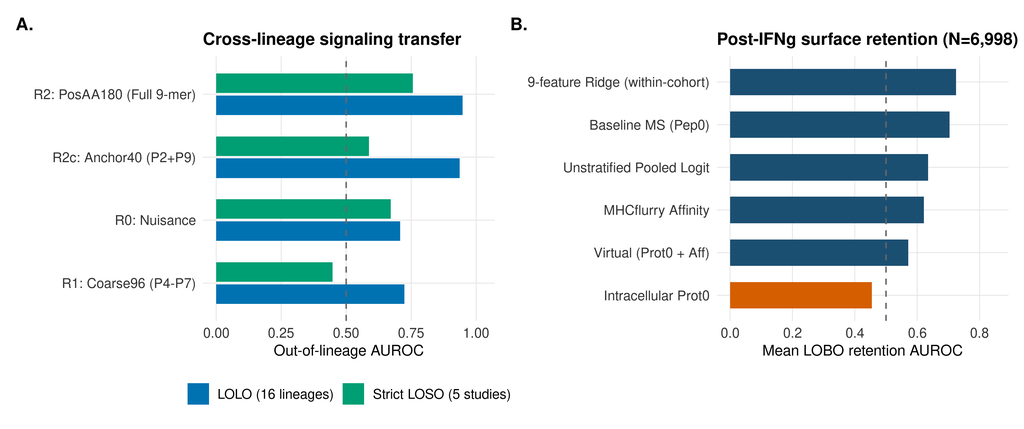

```r
cl_plot <- read_tsv(file.path(RES_DIR, "exp7_distributional_sensing", "exp7c_cross_lineage_study_transfer.tsv"), show_col_types = FALSE) |>
  filter(representation %in% c("R0_Quantity_Nuisance", "R1_Coarse96", "R2c_Anchor40", "R2_PosAA180")) |>
  mutate(Rep = recode(representation,
    R0_Quantity_Nuisance = "R0: Nuisance",
    R1_Coarse96 = "R1: Coarse96 (P4-P7)",
    R2c_Anchor40 = "R2c: Anchor40 (P2+P9)",
    R2_PosAA180 = "R2: PosAA180 (Full 9-mer)"
  )) |>
  pivot_longer(c(lolo_auroc, loso_strict_disjoint_lineage_auroc), names_to = "Split", values_to = "AUROC") |>
  mutate(Split = recode(Split, lolo_auroc = "LOLO (16 lineages)", loso_strict_disjoint_lineage_auroc = "Strict LOSO (5 studies)"))

p1 <- ggplot(cl_plot, aes(x = reorder(Rep, AUROC), y = AUROC, fill = Split)) +
  geom_col(position = position_dodge(width = 0.7), width = 0.62) +
  geom_hline(yintercept = 0.5, linetype = "dashed", color = GRAY) +
  coord_flip() +
  scale_fill_manual(values = c("LOLO (16 lineages)" = BLUE, "Strict LOSO (5 studies)" = TEAL)) +
  ylim(0, 1.02) +
  labs(x = NULL, y = "Out-of-lineage AUROC", fill = NULL, title = "Cross-lineage signaling transfer")

p2_df <- read_tsv(file.path(RES_DIR, "exp5_persistence_prediction", "lobo_persistence_metrics.tsv"), show_col_types = FALSE) |>
  filter(endpoint == "retained") |>
  group_by(method) |>
  summarise(AUROC = mean(auroc), .groups = "drop") |>
  mutate(Method = recode(method,
    Mechanistic_Censored = "9-feature Ridge (within-cohort)",
    Baseline_MS_Pep0 = "Baseline MS (Pep0)",
    MHCflurry_Affinity = "MHCflurry Affinity",
    Unstratified_Pooled_Logit = "Unstratified Pooled Logit",
    Virtual_Prot0_plus_Aff = "Virtual (Prot0 + Aff)",
    Intracellular_Prot0 = "Intracellular Prot0"
  ))

p2 <- ggplot(p2_df, aes(x = reorder(Method, AUROC), y = AUROC)) +
  geom_col(fill = ifelse(p2_df$Method == "Intracellular Prot0", ORANGE, NAVY), width = 0.62) +
  geom_hline(yintercept = 0.5, linetype = "dashed", color = GRAY) +
  coord_flip() +
  ylim(0, 0.85) +
  labs(x = NULL, y = "Mean LOBO retention AUROC", title = "Post-IFNg surface retention (N=6,998)")

tagged(p1 + p2)
```

**What do we see?**

Table 0.4 and Figure 0.1 synthesize both halves of the presentation-state thesis. On paired perturbation sensing across `16` human lineages (panel A), full `PosAA180` rises to `LOLO AUROC = 0.948` and strict disjoint-study `LOSO AUROC = 0.756`, whereas anchor-blind `Coarse96` (`0.724` / `0.448`) falls below `R0` nuisance (`0.708` / `0.672`) when unseen studies are held out. On baseline-to-post-IFN-$\gamma$ retention across `N = 6,998` ligands (panel B), `9`-feature within-cohort Ridge reaches mean `LOBO AUROC = 0.725` (`Baseline Pep0 = 0.704`), whereas unstratified pooled logit drops to `0.635` and baseline intracellular protein `Prot0` sits below chance at `0.455`. Proceed directly to **Report 01 — Mass-Spectrometry Data Loading, Scale Contrast & QC Audit** to inspect all 12 staged inputs row-by-row.